# Data Science Salaries 2023/2024

Reproducible Research Project

Dilara Ozdil, Eljan Abbaszada, Paula Gwanchele

2026-05-12

# 1 Set working directory to the current folder

```r
setwd(dirname(rstudioapi::getActiveDocumentContext()$path))
```

# 2 Introduction

This report investigates the determinants of data science salaries using a cross-sectional dataset of reported compensation. We combine exploratory data analysis (EDA) with a fixed-effects regression framework to quantify how experience, work model (remote/hybrid/on-site), company size, and year affect (log) salary, while absorbing country-level heterogeneity through location fixed effects. We then assess the robustness of the main findings to (i) restricting the sample to full-time employees, (ii) replacing company-location with employee-residence fixed effects, (iii) trimming the top 1% of salaries, and (iv) allowing the remote-work effect to vary by experience level.

# 3 Data

## 3.1 Dependencies

```r
required <- c("tidyverse", "fixest", "modelsummary", "scales")
to_install <- setdiff(required, rownames(installed.packages()))
if (length(to_install)) install.packages(to_install)

library(tidyverse)
library(scales)
library(fixest)
library(modelsummary)
```

## 3.2 Load the raw data

```r
raw_data <- read_csv("data_clean.csv")
glimpse(raw_data)
```

```
## Rows: 6,599
## Columns: 11
## $ job_title          <chr> "Data Engineer", "Data Engineer", "Data Scientist",…
## $ experience_level   <chr> "Mid-level", "Mid-level", "Senior-level", "Senior-l…
## $ employment_type    <chr> "Full-time", "Full-time", "Full-time", "Full-time",…
## $ work_models        <chr> "Remote", "Remote", "Remote", "Remote", "On-site", …
## $ work_year          <dbl> 2024, 2024, 2024, 2024, 2024, 2024, 2024, 2024, 202…
## $ employee_residence <chr> "United States", "United States", "United States", …
## $ salary_in_usd      <dbl> 148100, 98700, 140032, 100022, 120000, 62100, 25000…
## $ company_location   <chr> "United States", "United States", "United States", …
## $ company_size       <chr> "Medium", "Medium", "Medium", "Medium", "Medium", "…
## $ job_category       <chr> "Data Engineering", "Data Engineering", "Data Scien…
## $ log_salary         <dbl> 11.90564, 11.49984, 11.84963, 11.51315, 11.69525, 1…
```

## 3.3 Cleaning and feature construction

A single cleaning pipeline is reused by both the EDA and the econometric models, removing the duplicated cleaning logic from the two original scripts.

```r
cleaned_data <- raw_data %>%
  drop_na() %>%
  filter(salary_in_usd > 0) %>%
  mutate(
    experience_level = factor(
      experience_level,
      levels = c("Entry-level", "Mid-level", "Senior-level", "Executive-level")
    ),
    company_size       = factor(company_size, levels = c("Small", "Medium", "Large")),
    work_year          = as.factor(work_year),
    employment_type    = as.factor(employment_type),
    work_models        = as.factor(work_models),
    company_location   = as.factor(company_location),
    employee_residence = as.factor(employee_residence),
    log_salary         = log(salary_in_usd),
    job_category = case_when(
      str_detect(job_title, "Data Scientist")      ~ "Data Science",
      str_detect(job_title, "Data Engineer")       ~ "Data Engineering",
      str_detect(job_title, "Analyst")             ~ "Data Analysis",
      str_detect(job_title, "Machine Learning|ML") ~ "Machine Learning",
      str_detect(job_title, "Manager|Lead|Head")   ~ "Management",
      TRUE                                          ~ "Other"
    )
  ) %>%
  select(-any_of(c("salary", "salary_currency")))

write_csv(cleaned_data, "data_clean.csv")
dim(cleaned_data)
```

```
## [1] 6599   11
```

# 4 Exploratory Data Analysis

## 4.1 Experience level vs. salary

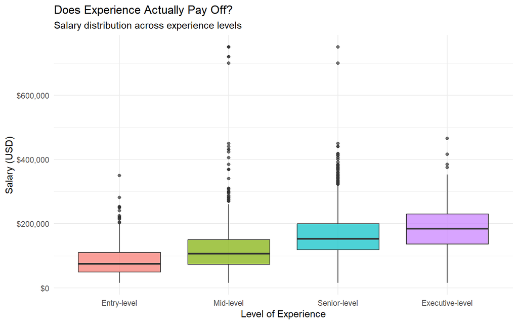

```r
ggplot(cleaned_data, aes(x = experience_level, y = salary_in_usd, fill = experience_level)) +
  geom_boxplot(alpha = 0.7) +
  scale_y_continuous(labels = label_dollar()) +
  labs(title = "Does Experience Actually Pay Off?",
       subtitle = "Salary distribution across experience levels",
       x = "Level of Experience", y = "Salary (USD)") +
  theme_minimal() + theme(legend.position = "none")
```

## 4.2 Salary distribution

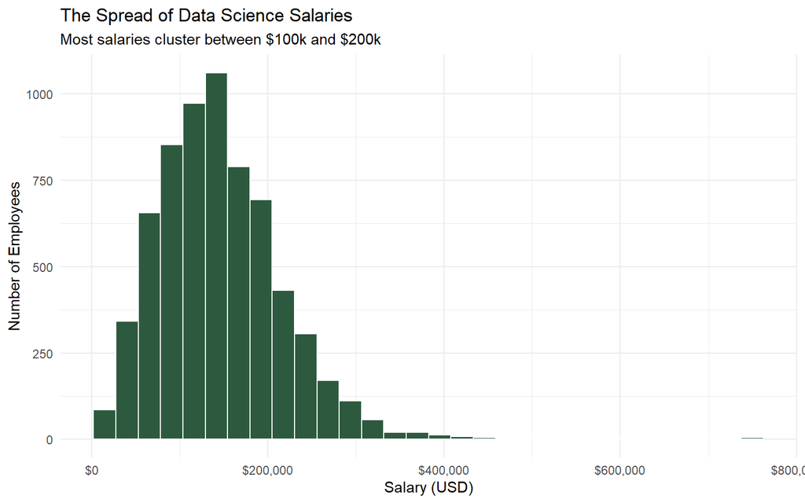

```r
ggplot(cleaned_data, aes(x = salary_in_usd)) +
  geom_histogram(fill = "#2d5a3f", color = "white", bins = 30) +
  scale_x_continuous(labels = label_dollar()) +
  labs(title = "The Spread of Data Science Salaries",
       subtitle = "Most salaries cluster between $100k and $200k",
       x = "Salary (USD)", y = "Number of Employees") +
  theme_minimal()
```

## 4.3 Average salary by job category

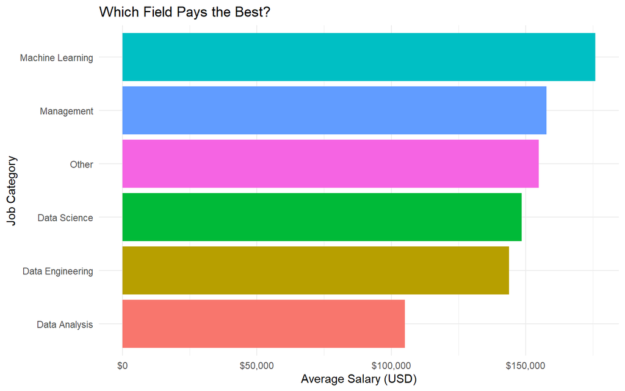

```r
category_summary <- cleaned_data %>%
  group_by(job_category) %>%
  summarise(avg_salary = mean(salary_in_usd), .groups = "drop") %>%
  arrange(desc(avg_salary))

ggplot(category_summary,
       aes(x = reorder(job_category, avg_salary), y = avg_salary, fill = job_category)) +
  geom_col() + coord_flip() +
  scale_y_continuous(labels = label_dollar()) +
  labs(title = "Which Field Pays the Best?",
       x = "Job Category", y = "Average Salary (USD)") +
  theme_minimal() + theme(legend.position = "none")
```

## 4.4 Remote vs. on-site

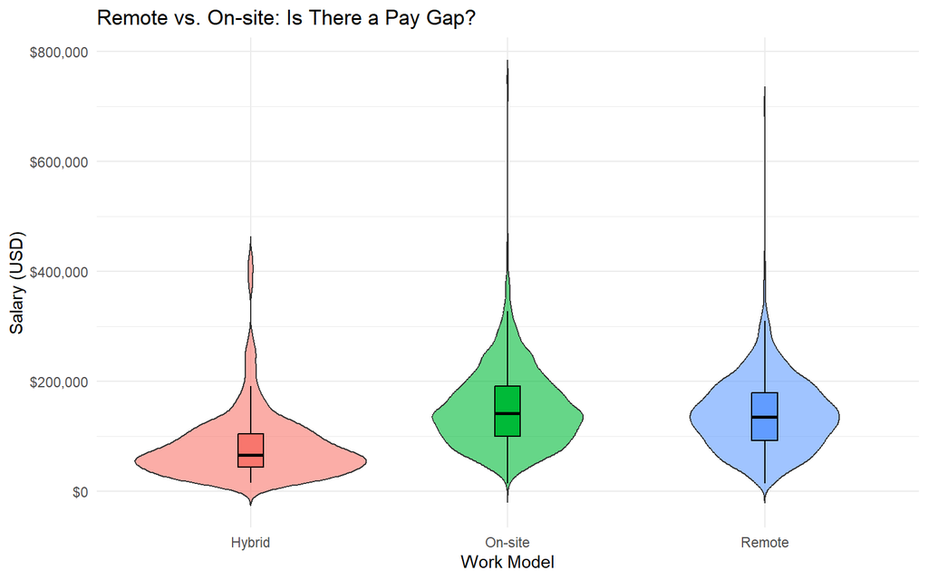

```r
ggplot(cleaned_data, aes(x = work_models, y = salary_in_usd, fill = work_models)) +
  geom_violin(trim = FALSE, alpha = 0.6) +
  geom_boxplot(width = 0.1, color = "black", outlier.shape = NA) +
  scale_y_continuous(labels = label_dollar()) +
  labs(title = "Remote vs. On-site: Is There a Pay Gap?",
       x = "Work Model", y = "Salary (USD)") +
  theme_minimal() + theme(legend.position = "none")
```

## 4.5 Company size

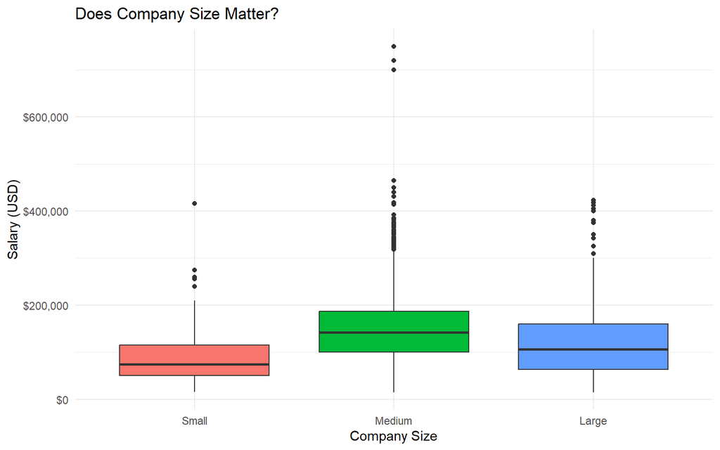

```r
ggplot(cleaned_data, aes(x = company_size, y = salary_in_usd, fill = company_size)) +
  geom_boxplot() +
  scale_y_continuous(labels = label_dollar()) +
  labs(title = "Does Company Size Matter?",
       x = "Company Size", y = "Salary (USD)") +
  theme_minimal() + theme(legend.position = "none")
```

## 4.6 Top 10 locations by average salary

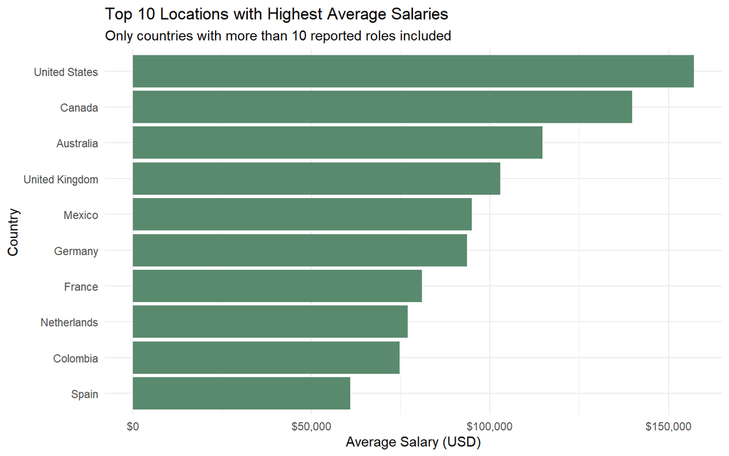

```r
geo_summary <- cleaned_data %>%
  group_by(company_location) %>%
  filter(n() > 10) %>%
  summarise(avg_salary = mean(salary_in_usd), .groups = "drop") %>%
  arrange(desc(avg_salary)) %>%
  slice_head(n = 10)

ggplot(geo_summary, aes(x = reorder(company_location, avg_salary), y = avg_salary)) +
  geom_col(fill = "#5a8a6e") + coord_flip() +
  scale_y_continuous(labels = label_dollar()) +
  labs(title = "Top 10 Locations with Highest Average Salaries",
       subtitle = "Only countries with more than 10 reported roles included",
       x = "Country", y = "Average Salary (USD)") +
  theme_minimal()
```

# 5 Model

```r
model1 <- feols(
  log_salary ~
    experience_level +
    work_models +
    company_size +
    work_year |
    company_location,

  data = cleaned_data,

  vcov = "hetero"
)
summary(model1)
```

```
## OLS estimation, Dep. Var.: log_salary
## Observations: 6,581
## Fixed-effects: company_location: 57
## Standard-errors: Heteroskedasticity-robust
##                                  Estimate Std. Error   t value   Pr(>|t|)
## experience_levelMid-level        0.319570   0.022049 14.493956  < 2.2e-16 ***
## experience_levelSenior-level     0.589480   0.020541 28.697087  < 2.2e-16 ***
## experience_levelExecutive-level  0.776942   0.032577 23.849254  < 2.2e-16 ***
## work_modelsOn-site               0.094438   0.038746  2.437359 1.4822e-02 *
## work_modelsRemote                0.056425   0.037854  1.490594 1.3612e-01
## company_sizeMedium               0.155068   0.043267  3.583981 3.4087e-04 ***
## company_sizeLarge                0.183858   0.043882  4.189796 2.8289e-05 ***
## work_year2021                   -0.004570   0.068649 -0.066573 9.4692e-01
## work_year2022                    0.005000   0.065542  0.076288 9.3919e-01
## work_year2023                    0.074351   0.066156  1.123863 2.6111e-01
## work_year2024                    0.075900   0.068741  1.104146 2.6957e-01
## ---
## Signif. codes:  0 '***' 0.001 '**' 0.01 '*' 0.05 '.' 0.1 ' ' 1
## RMSE: 0.403023     Adj. R2: 0.417205
##                  Within R2: 0.187955
```

## 5.1 Full-time employees only

```r
cleaned_data_fulltime <- cleaned_data %>%
  filter(employment_type == "Full-time")

model2 <- feols(
  log_salary ~
    experience_level +
    work_models +
    company_size +
    work_year |
    company_location,

  data = cleaned_data_fulltime,

  vcov = "hetero"
)
summary(model2)
```

```
## OLS estimation, Dep. Var.: log_salary
## Observations: 6,537
## Fixed-effects: company_location: 57
## Standard-errors: Heteroskedasticity-robust
##                                  Estimate Std. Error   t value  Pr(>|t|)
## experience_levelMid-level        0.317821   0.021948 14.480722 < 2.2e-16 ***
## experience_levelSenior-level     0.584756   0.020499 28.525454 < 2.2e-16 ***
## experience_levelExecutive-level  0.767264   0.032310 23.747060 < 2.2e-16 ***
## work_modelsOn-site               0.083990   0.038300  2.192964 0.0283454 *
## work_modelsRemote                0.048041   0.037514  1.280634 0.2003683
## company_sizeMedium               0.125672   0.041633  3.018536 0.0025499 **
## company_sizeLarge                0.158123   0.042274  3.740415 0.0001853 ***
## work_year2021                   -0.020637   0.069505 -0.296916 0.7665400
## work_year2022                   -0.005215   0.067409 -0.077368 0.9383334
## work_year2023                    0.064892   0.068162  0.952027 0.3411189
## work_year2024                    0.067448   0.070632  0.954925 0.3396514
## ---
## Signif. codes:  0 '***' 0.001 '**' 0.01 '*' 0.05 '.' 0.1 ' ' 1
## RMSE: 0.399932     Adj. R2: 0.411489
##                  Within R2: 0.182948
```

## 5.2 Employee-residence fixed effects

```r
model3 <- feols(
  log_salary ~
    experience_level +
    work_models +
    company_size +
    work_year |
    employee_residence,

  data = cleaned_data,

  vcov = "hetero"
)
summary(model3)
```

```
## OLS estimation, Dep. Var.: log_salary
## Observations: 6,573
## Fixed-effects: employee_residence: 61
## Standard-errors: Heteroskedasticity-robust
##                                  Estimate Std. Error   t value  Pr(>|t|)
## experience_levelMid-level        0.315612   0.022047 14.315312 < 2.2e-16 ***
## experience_levelSenior-level     0.580040   0.020584 28.179227 < 2.2e-16 ***
## experience_levelExecutive-level  0.765084   0.031693 24.140449 < 2.2e-16 ***
## work_modelsOn-site               0.115846   0.036659  3.160069 0.0015846 **
## work_modelsRemote                0.088142   0.035917  2.454035 0.0141524 *
## company_sizeMedium               0.071116   0.044221  1.608189 0.1078423
## company_sizeLarge                0.115596   0.044555  2.594428 0.0094961 **
## work_year2021                   -0.057095   0.060117 -0.949735 0.3422824
## work_year2022                   -0.066373   0.057159 -1.161193 0.2456059
## work_year2023                    0.006300   0.057651  0.109269 0.9129923
## work_year2024                    0.003890   0.060417  0.064387 0.9486641
## ---
## Signif. codes:  0 '***' 0.001 '**' 0.01 '*' 0.05 '.' 0.1 ' ' 1
## RMSE: 0.399377     Adj. R2: 0.424603
##                  Within R2: 0.178992
```

## 5.3 Trimming the top 1% of salaries

```r
salary_cutoff <- quantile(cleaned_data$salary_in_usd, 0.99)

cleaned_data_trimmed <- cleaned_data %>%
  filter(salary_in_usd < salary_cutoff)

model4 <- feols(
  log_salary ~
    experience_level +
    work_models +
    company_size +
    work_year |
    company_location,

  data = cleaned_data_trimmed,

  vcov = "hetero"
)
summary(model4)
```

```
## OLS estimation, Dep. Var.: log_salary
## Observations: 6,515
## Fixed-effects: company_location: 57
## Standard-errors: Heteroskedasticity-robust
##                                 Estimate Std. Error   t value   Pr(>|t|)
## experience_levelMid-level       0.306057   0.021670 14.123456  < 2.2e-16 ***
## experience_levelSenior-level    0.580920   0.020354 28.540872  < 2.2e-16 ***
## experience_levelExecutive-level 0.760460   0.032090 23.697760  < 2.2e-16 ***
## work_modelsOn-site              0.102666   0.037470  2.739989 6.1610e-03 **
## work_modelsRemote               0.071710   0.036622  1.958121 5.0259e-02 .
## company_sizeMedium              0.156018   0.042812  3.644263 2.7027e-04 ***
## company_sizeLarge               0.174353   0.043346  4.022363 5.8276e-05 ***
## work_year2021                   0.021618   0.065194  0.331601 7.4020e-01
## work_year2022                   0.033234   0.061874  0.537113 5.9121e-01
## work_year2023                   0.100833   0.062397  1.615988 1.0615e-01
## work_year2024                   0.085196   0.064735  1.316075 1.8820e-01
## ---
## Signif. codes:  0 '***' 0.001 '**' 0.01 '*' 0.05 '.' 0.1 ' ' 1
## RMSE: 0.388659     Adj. R2: 0.433696
##                  Within R2: 0.198968
```

## 5.4 Heterogeneous effect of remote work by experience

```r
model5 <- feols(
  log_salary ~
    experience_level * work_models +
    company_size +
    work_year |
    company_location,

  data = cleaned_data,

  vcov = "hetero"
)
summary(model5)
```

```
## OLS estimation, Dep. Var.: log_salary
## Observations: 6,581
## Fixed-effects: company_location: 57
## Standard-errors: Heteroskedasticity-robust
##                                                     Estimate Std. Error
## experience_levelMid-level                           0.343409   0.075560
## experience_levelSenior-level                        0.619033   0.083473
## experience_levelExecutive-level                     1.115405   0.143974
## work_modelsOn-site                                  0.191847   0.065791
## work_modelsRemote                                   0.028368   0.066908
## company_sizeMedium                                  0.147008   0.043080
## company_sizeLarge                                   0.179725   0.043826
## work_year2021                                      -0.001642   0.067986
## work_year2022                                       0.002267   0.064911
## work_year2023                                       0.071562   0.065461
## work_year2024                                       0.072747   0.067980
## experience_levelMid-level:work_modelsOn-site       -0.065259   0.081521
## experience_levelSenior-level:work_modelsOn-site    -0.094003   0.087791
## experience_levelExecutive-level:work_modelsOn-site -0.478176   0.152330
## experience_levelMid-level:work_modelsRemote         0.018247   0.084400
## experience_levelSenior-level:work_modelsRemote      0.050915   0.090276
## experience_levelExecutive-level:work_modelsRemote  -0.194188   0.151842
##                                                      t value   Pr(>|t|)
## experience_levelMid-level                           4.544838 5.5971e-06 ***
## experience_levelSenior-level                        7.415999 1.3606e-13 ***
## experience_levelExecutive-level                     7.747288 1.0821e-14 ***
## work_modelsOn-site                                  2.915993 3.5577e-03 **
## work_modelsRemote                                   0.423984 6.7159e-01
## company_sizeMedium                                  3.412463 6.4771e-04 ***
## company_sizeLarge                                   4.100886 4.1659e-05 ***
## work_year2021                                      -0.024156 9.8073e-01
## work_year2022                                       0.034920 9.7214e-01
## work_year2023                                       1.093207 2.7434e-01
## work_year2024                                       1.070136 2.8460e-01
## experience_levelMid-level:work_modelsOn-site       -0.800525 4.2344e-01
## experience_levelSenior-level:work_modelsOn-site    -1.070751 2.8432e-01
## experience_levelExecutive-level:work_modelsOn-site -3.139086 1.7023e-03 **
## experience_levelMid-level:work_modelsRemote         0.216193 8.2884e-01
## experience_levelSenior-level:work_modelsRemote      0.563995 5.7278e-01
## experience_levelExecutive-level:work_modelsRemote  -1.278882 2.0098e-01
## ---
## Signif. codes:  0 '***' 0.001 '**' 0.01 '*' 0.05 '.' 0.1 ' ' 1
## RMSE: 0.402039     Adj. R2: 0.419514
##                  Within R2: 0.191916
```

# 6 Results

The main specification confirms the patterns visible in the EDA: salaries rise sharply with experience, and there is meaningful variation across work models and company sizes once country effects are absorbed. Coefficients are in log points and approximate percentage changes relative to the omitted category.

## 6.1 Combined regression table

```r
modelsummary(
  list(
    "Main Model"     = model1,
    "Full-Time Only" = model2,
    "Residence FE"   = model3,
    "Trimmed Sample" = model4,
    "Remote x Exp."  = model5
  ),
  stars  = TRUE,
  output = "markdown"
)
```

Main Model

Full-Time Only

Residence FE

Trimmed Sample

Remote x Exp.

experience_levelMid-level

0.320***

0.318***

0.316***

0.306***

0.343***

(0.022)

(0.022)

(0.022)

(0.022)

(0.076)

experience_levelSenior-level

0.589***

0.585***

0.580***

0.581***

0.619***

(0.021)

(0.020)

(0.021)

(0.020)

(0.083)

experience_levelExecutive-level

0.777***

0.767***

0.765***

0.760***

1.115***

(0.033)

(0.032)

(0.032)

(0.032)

(0.144)

work_modelsOn-site

0.094*

0.084*

0.116**

0.103**

0.192**

(0.039)

(0.038)

(0.037)

(0.037)

(0.066)

work_modelsRemote

0.056

0.048

0.088*

0.072+

0.028

(0.038)

(0.038)

(0.036)

(0.037)

(0.067)

company_sizeMedium

0.155***

0.126**

0.071

0.156***

0.147***

(0.043)

(0.042)

(0.044)

(0.043)

(0.043)

company_sizeLarge

0.184***

0.158***

0.116**

0.174***

0.180***

(0.044)

(0.042)

(0.045)

(0.043)

(0.044)

work_year2021

-0.005

-0.021

-0.057

0.022

-0.002

(0.069)

(0.070)

(0.060)

(0.065)

(0.068)

work_year2022

0.005

-0.005

-0.066

0.033

0.002

(0.066)

(0.067)

(0.057)

(0.062)

(0.065)

work_year2023

0.074

0.065

0.006

0.101

0.072

(0.066)

(0.068)

(0.058)

(0.062)

(0.065)

work_year2024

0.076

0.067

0.004

0.085

0.073

(0.069)

(0.071)

(0.060)

(0.065)

(0.068)

experience_levelMid-level × work_modelsOn-site

-0.065

(0.082)

experience_levelSenior-level × work_modelsOn-site

-0.094

(0.088)

experience_levelExecutive-level × work_modelsOn-site

-0.478**

(0.152)

experience_levelMid-level × work_modelsRemote

0.018

(0.084)

experience_levelSenior-level × work_modelsRemote

0.051

(0.090)

experience_levelExecutive-level × work_modelsRemote

-0.194

(0.152)

Num.Obs.

6581

6537

6573

6515

6581

R2

0.423

0.418

0.431

0.440

0.426

R2 Adj.

0.417

0.411

0.425

0.434

0.420

R2 Within

0.188

0.183

0.179

0.199

0.192

R2 Within Adj.

0.187

0.182

0.178

0.198

0.190

AIC

6850.9

6705.4

6731.3

6310.7

6830.8

BIC

7312.8

7166.8

7220.3

6771.9

7333.4

RMSE

0.40

0.40

0.40

0.39

0.40

FE: company_location

X

X

X

X

FE: employee_residence

X

- p < 0.1, * p < 0.05, ** p < 0.01, *** p < 0.001

# 7 Robustness

Columns 2–5 of the table above re-estimate the wage equation under alternative modelling choices.

- **Full-time only (model 2):** restricting to full-time employees removes part-time and contract workers as a source of noise.
- **Employee-residence (model 3):** absorbing the worker’s country of residence rather than the company’s location addresses concerns about cross-border remote arrangements.
- **Trimmed sample (model 4):** removing the top 1% of salaries checks that extreme top earners are not driving the experience premium.
- **Remote × experience (model 5):** allowing the remote-work effect to vary by experience level tests whether the average premium hides meaningful heterogeneity.

# 8 Conclusion